# Magic 关键字

- Magic 关键字是可以在单元格中运行的特殊命令，能让你控制 notebook 本身或执行系统调用（例如更改目录）。例如，在 notebook 中可以使用 %matplotlib 将 matplotlib 设置为以交互方式工作。
- Magic 命令的前面带有一个或两个百分号（% 或 %%），分别对应行 Magic 命令和单元格 Magic 命令。行 Magic 命令仅应用于编写 Magic 命令时所在的行，而单元格 Magic 命令应用于整个单元格。
- 注意：这些 Magic 关键字是特定于普通 Python 内核的关键字。如果使用其他内核，这些关键字很有可能无效。

### 代码计时

```python
from math import sqrt

def fibo1(n):
    if n==0:
        return 0
    elif n==1:
        return 1
    return fibo1(n - 1) + fibo1(n - 2)

def fibo2(n):
    return ((1+sqrt(5)) ** n - (1-sqrt(5))** n)/(2**n*sqrt(5))
```

```python
%time fibo1(32)
```

```
Wall time: 997 ms
```

```
2178309
```

```python
%time fibo2(32)
```

```
Wall time: 0 ns
```

```
2178309.0000000023
```

- 如果要测算整个单元格的运行时间，请使用 %%timeit：

```python
%%timeit
f = []
for i in range(2):
    f.append(i)
```

```
414 ns ± 4.7 ns per loop (mean ± std. dev. of 7 runs, 1000000 loops each)
```

## 在 notebook 中嵌入可视化内容

- 如前所述，notebook 允许你将图像与文本和代码一起嵌入。这在你使用 matplotlib 或其他绘图包创建可视化内容时最为有用。在 notebook 中可以使用 %matplotlib 将 matplotlib 设置为以交互方式工作。默认情况下，图形呈现在各自的窗口中。但是，你可以通过命令传递参数，以选择特定的“后端”（呈现图像的软件）。要直接在 notebook 中呈现图形，应将通过命令 %matplotlib inline 内联后端一起使用。
- 提示：在分辨率较高的屏幕（例如 Retina 显示屏）上，notebook 中的默认图像可能会显得模糊。可以在 %matplotlib inline 之后使用 %config InlineBackend.figure_format = 'retina' 来呈现分辨率较高的图像。

```python
%matplotlib inline
%config InlineBackend.figure_format = 'retina'
import matplotlib.pyplot as plt
import numpy as np
```

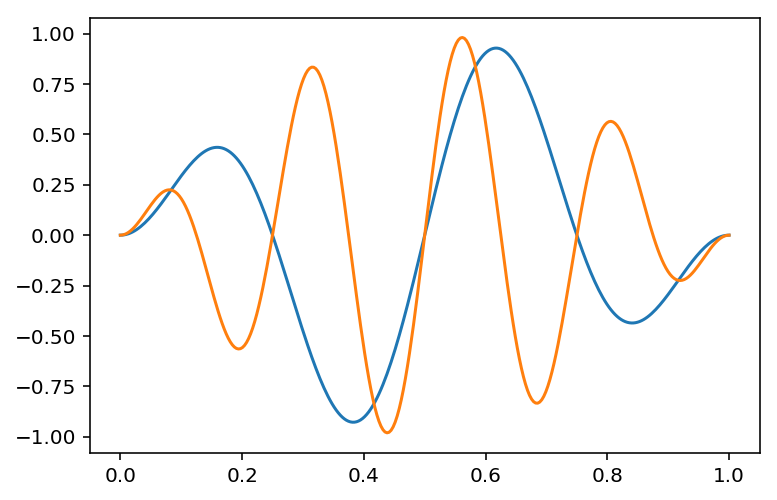

```python
x = np.linspace(0,1,300)
for w in range(2,6,2):
    plt.plot(x,np.sin(np.pi*x) * np.sin(2*w*np.pi*x))
```

## 在 notebook 中进行调试

- 对于 Python 内核，可以使用 Magic 命令 %pdb 开启交互式调试器。出错时，你能检查当前命名空间中的变量。

```python
%pdb
```

```python
n = 'hello'
m = 12
sum(n,m)
```

[output not shown]